# Batch_correction

# Contrast

The makeContrasts function is used to create linear combinations (contrasts) of coefficients from a linear model fitted to the data. * These contrasts are often used to test specific hypotheses about the differences between experimental conditions.*

Ok, as I undestand, the contrast mark the change from condition_m to condition_n. FOr condition m and n I expect weather 1 or -1, and the other conditions should be 0 because they should not intervine (?) and if they do is because they are related. Batches here is 0 in all the 3 changes, so it is not impacting the age.

```r
fit = fit_pos
title = "limma_combat_microarray_pos.csv"

mvso <- makeContrasts(conditions1 - conditions2, levels = colnames(coef(fit)))
yvsm <- makeContrasts(conditions3 - conditions1, levels = colnames(coef(fit)))
yvso <- makeContrasts(conditions3 - conditions2, levels = colnames(coef(fit)))

mvso
```

```
##              Contrasts
## Levels        conditions1 - conditions2
##   conditions1                         1
##   conditions2                        -1
##   conditions3                         0
##   batches                             0
```

# Differential expression analysis

Now that we saw the contrast, contr is condition1 vs condition2 (MiddleAge vs Old) empirical Bayes moderation

```r
tmp <- contrasts.fit(fit, mvso)
tmp <- eBayes(tmp)
```

```r
top.table <- topTable(tmp, sort.by = "P", n = Inf)%>%
  mutate(absFLC = abs(logFC)) %>%
  filter(absFLC >= 0.3) %>%
  filter(adj.P.Val < 0.05)

write.csv(top.table, title)
```

# Volcano plot

Let’s make our friend Volcanito

[figure not shown]

```r
library(ggplot2)

top.table_nF <- topTable(tmp, sort.by = "P", n = Inf)
ggplot(top.table_nF, aes(x = logFC, y = -log10(adj.P.Val))) +
  geom_point(aes(color = ifelse(abs(logFC) >= 1 & (adj.P.Val) < 0.05, "NS", "S"))) +
  theme_minimal() +
  labs(x = "log2(Fold Change)", y = "log10 adj.P.Val", color = "Significant", title = "Pre adjustment Volcano plot")
```

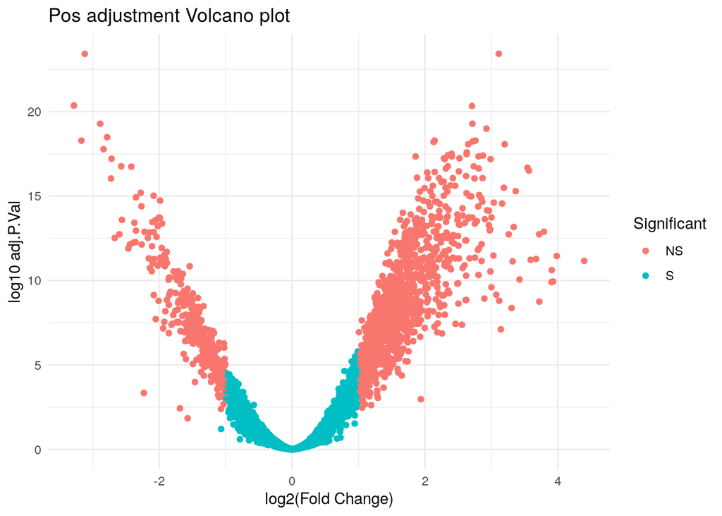

```r
library(ggplot2)

top.table_nF <- topTable(tmp, sort.by = "P", n = Inf)
ggplot(top.table_nF, aes(x = logFC, y = -log10(adj.P.Val))) +
  geom_point(aes(color = ifelse(abs(logFC) >= 1 & (adj.P.Val) < 0.05, "NS", "S"))) +
  theme_minimal() +
  labs(x = "log2(Fold Change)", y = "log10 adj.P.Val", color = "Significant", title = "Pos adjustment Volcano plot")
```